# 213070110_CA2

```
Sampling rate,  8000
```

[interactive chart not shown]

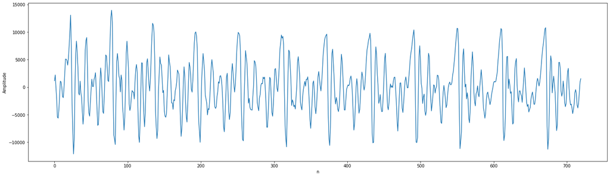

```python
import numpy as np
from scipy import signal
from scipy.signal import windows, freqz
from scipy.io import wavfile
import math
from scipy.fft import fft,fftfreq
import IPython
from matplotlib import patches
import matplotlib.pyplot as plt
%matplotlib inline

plt.rcParams["figure.figsize"] = [25,7]


sr,data= wavfile.read('aa.wav')                    #reading the wavfile
print("Sampling rate, ",sr)
display(IPython.display.Audio('aa.wav'))           #displaying it
plt.plot(data)
plt.ylabel('Amplitude')
plt.xlabel('n')
```

The above is a plot of the original wavfile

[interactive chart not shown]

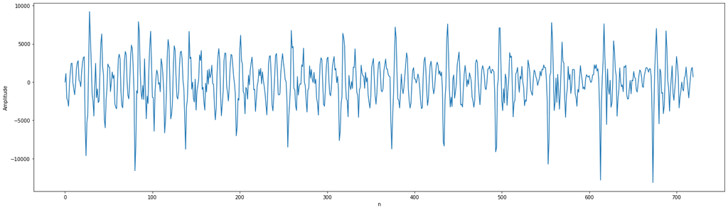

```python
filt = np.zeros(len(data))
alpha = 0.95
for i in range(1, len(data)):
    filt[i] = data[i] - alpha*data[i-1];

display(IPython.display.Audio(filt, rate=8000))
plt.plot(filt)
plt.ylabel('Amplitude')
plt.xlabel('n')
```

alpha is taken as 0.95 here for the pre-emphasis and the pre-emphasized signal is plotted

pre -emphasis filter is (1-alpha * z^(-1))

So,Y(z)=X(z)(1-alpha *z^(-1)) which gives y[n]=x[n]-alpha* x[n-1] as the pre-emphasized signal

```
window size = 240
window size = 240
```

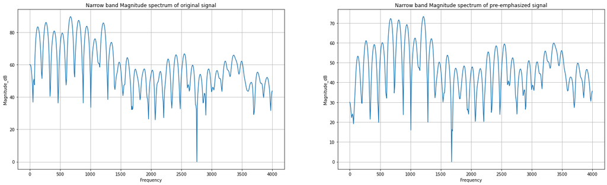

```python
def hamming(d,window_length):             #defining a function for hamming window
    L =int(window_length*sr)
    w= windows.hamming(L)                         #generating a hamming window
    print("window size =",L)
    n=(N//2)+1                             #size of one side(assuming positive side here) of the spectrum
    n1=(L+1)//2                             #half of the window size using rounding
    n2=L//2                                #half of the window size using floor

    buffer=np.zeros(N)                  #assume a signal of size = DFT size i.e.,N

    x=d[240:240+L]     #taking some samples from the required signal whose size=window size(here from 240 to 240+window size)
    y=x*w                        #windowing the signal by multiplying with the window function

    for i in range(0,L):
        if (i>=0) and (i<n2):
            buffer[i]=y[n2+i]

    buffer[-n2:]=y[:n2]

    Y=fft(buffer)                                 #dft of the buffer
    absY = np.abs(Y[:n])                          #absolute value of dft
    output=-1*20*np.log10(absY)
    mag=max(output)-output                        #required magnitude to be plotted
    return y,mag                                  #return the window and also the value of magnitude



N=1024                             #The DFT size is assumed as 1024 samples.DFT size is always greater than the window size
window_length=30/1000

window_original,magnitude_original=hamming(data,window_length)       #taking window and magnitude of original wavfile
r=np.arange(0,(sr/2)+1,sr/float(N))
plt.subplot(1,2,1)
plt.grid()
plt.plot(r,magnitude_original)                                     #plotting its magnitude spectrum
plt.title('Narrow band Magnitude spectrum of original signal')
plt.ylabel('Magnitude_dB')
plt.xlabel('Frequency')

window,magnitude=hamming(filt,window_length)                   #taking window and magnitude of the pre-emphasized signal
plt.subplot(1,2,2)
plt.grid()
plt.plot(r,magnitude)                                          #plotting its magnitude spectrum
plt.title('Narrow band Magnitude spectrum of pre-emphasized signal')
plt.ylabel('Magnitude_dB')
plt.xlabel('Frequency')
```

Narrow band magnitude spectrum of slice using a Hamming window of duration = 30 ms is plotted for signal before pre-emphasis and after pre-emphasis.

```python
def LP(signal, p):
    R = np.correlate(signal,signal, mode = 'full')       #applying autocorrelation on the window obtained
    R = R[-(len(signal)):len(R)];       #Keeping autocorrelation values for positive values of i in summation(x[n]x[n-i])

#Levinson Algorithm
    E = np.zeros(p+1)       # error values are stored
    a = np.zeros((p+1,p+1))
    C = np.zeros(p+1)
    k=np.zeros(p+1)
    E[0] = R[0]                      #Initial Condition
    for i in range(1, p+1):                 # i = {1,2,.....p}
        s = 0
        for j in range(1, i):               # j = {1,2,..i-1}
            s = s + a[i-1][j] * R[i-j]
        k[i] = (R[i] - s)/E[i-1]
        a[i][i] = k[i]
        for j in range(1, i):                # j = {1,2,..i-1}
            a[i][j] = a[i-1][j] - k[i] * a[i-1][i-j]
        E[i] = (1 - (k[i]*k[i])) * E[i-1]
        C[i] = np.sqrt(E[i])                   #gain
        a[i][0] = 1
    return(C, a , E)

C1, a1,E1 = LP(window, 10)               # gain, LP coefficients,error
print(C1,a1)
```

```
[    0.         20058.51601538 17197.01933469 15657.81321431
 15441.68580839 15267.4599599  14992.82783309 14712.31310423
 11978.02988378 11472.46446395 11337.05712869] [[ 0.          0.          0.          0.          0.          0.
   0.          0.          0.          0.          0.        ]
 [ 1.          0.63677182  0.          0.          0.          0.
   0.          0.          0.          0.          0.        ]
 [ 1.          0.96454776 -0.51474629  0.          0.          0.
   0.          0.          0.          0.          0.        ]
 [ 1.          0.7516907  -0.11588805 -0.4135184   0.          0.
   0.          0.          0.          0.          0.        ]
 [ 1.          0.68322148 -0.13507646 -0.28905557 -0.16557719  0.
   0.          0.          0.          0.          0.        ]
 [ 1.          0.70802401 -0.09177757 -0.26882188 -0.26791991  0.14979436
   0.          0.          0.          0.          0.        ]
 [ 1.          0.73630801 -0.14236591 -0.31958052 -0.28524925  0.28348265
  -0.18881888  0.          0.          0.          0.        ]
 [ 1.          0.69995374 -0.08778552 -0.37450104 -0.34677974  0.25607221
  -0.04705368 -0.19253518  0.          0.          0.        ]
 [ 1.          0.5881573  -0.11510746 -0.22581153 -0.54813899  0.03861646
  -0.09802675  0.21389618 -0.58065459  0.          0.        ]
 [ 1.          0.75507299 -0.17659432 -0.19763264 -0.55923973  0.19618517
  -0.03311469  0.24698511 -0.74972702  0.28746124  0.        ]
 [ 1.          0.71103761 -0.06174574 -0.2354676  -0.55416698  0.16613212
   0.05255368  0.2772599  -0.72267503  0.17179372  0.15318719]]
```

Levinson-Durbin algorithm is an iterative method of computing the predictor coefficients

The autocorrelation function of the pre-emphasized windowed signal is found.

The error,gain and LP coefficients are calculated by the above algorithm

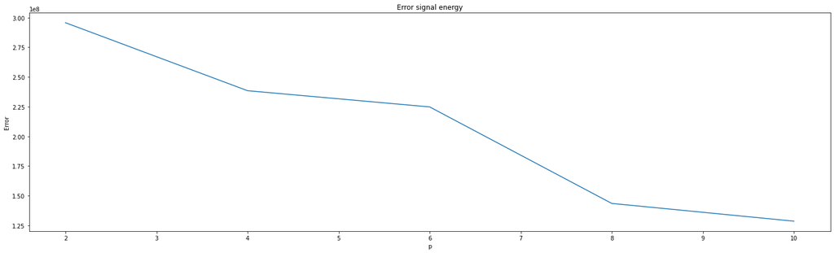

```python
P=[2,4,6,8,10]
plt.plot(P,C1[P]*C1[P])
plt.title('Error signal energy')
plt.ylabel('Error')
plt.xlabel('p')
```

The error signal energy which is the square of gain is plotted against p. We can observe error is decreasing with increasing number of poles.

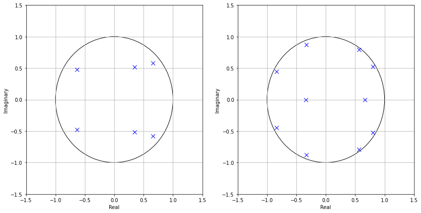

```python
plt.rcParams["figure.figsize"]=[14,7]
def poleZeroPlot(g,m):
    m[1:len(m)] = -m[1:len(m)];
    g=[g]
    z, pole, k = signal.tf2zpk(g, m)                     #get the zeroes, poles and gain
    pole = pole[pole!=0]
    circle=patches.Circle((0,0),1,fill=False)              #for unit circle
    ax.add_patch(circle)
    plt.ylim((-1.5, 1.5))
    plt.xlim((-1.5,1.5))
    plt.grid()
    plt.xlabel("Real")
    plt.ylabel("Imaginary")

        # Plot the poles and set marker properties
    poles = plt.plot(pole.real, pole.imag, 'x', color='b', markersize=8)       #poles are denoted by x


        # Plot the zeros and set marker properties
    zeros = plt.plot(z.real, z.imag,  'o', markersize=8)                       #zeroes are denoted by o


ax=plt.subplot(1,2,1)
poleZeroPlot(C1[6],a1[6])                    #pole-zero plot for p=6
ax=plt.subplot(1,2,2)
poleZeroPlot(C1[10],a1[10])                  #pole-zero plot for p=10
```

The above are the pole zero-plots for p=6 and p=10 respectively

```
For LP order 2
Gain is  17197.019334689372
LP coefficients
[ 1.          0.96454776 -0.51474629  0.          0.          0.
  0.          0.          0.          0.          0.        ]
```

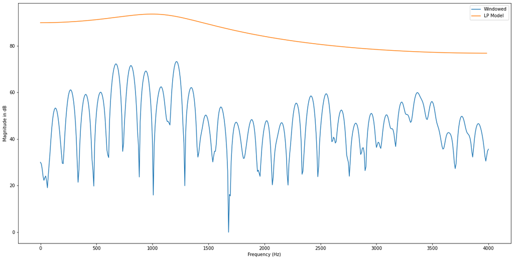

```
For LP order 4
Gain is  15441.685808387723
LP coefficients
[ 1.          0.68322148 -0.13507646 -0.28905557 -0.16557719  0.
  0.          0.          0.          0.          0.        ]
```

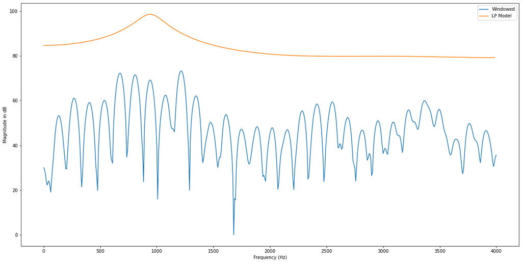

```
For LP order 6
Gain is  14992.827833089368
LP coefficients
[ 1.         -0.73630801  0.14236591  0.31958052  0.28524925 -0.28348265
  0.18881888 -0.         -0.         -0.         -0.        ]
```

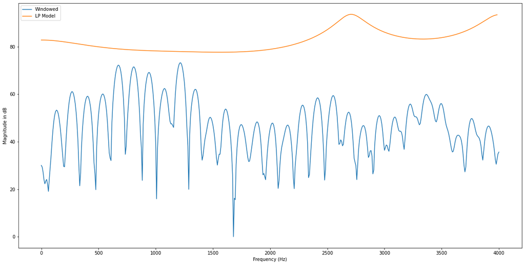

```
For LP order 8
Gain is  11978.029883784566
LP coefficients
[ 1.          0.5881573  -0.11510746 -0.22581153 -0.54813899  0.03861646
 -0.09802675  0.21389618 -0.58065459  0.          0.        ]
```

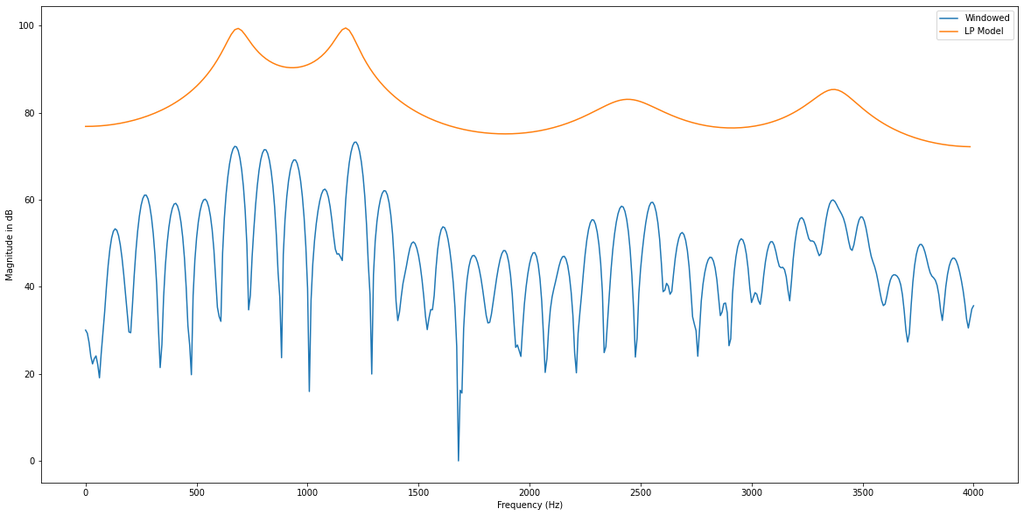

```
For LP order 10
Gain is  11337.057128692222
LP coefficients
[ 1.         -0.71103761  0.06174574  0.2354676   0.55416698 -0.16613212
 -0.05255368 -0.2772599   0.72267503 -0.17179372 -0.15318719]
```

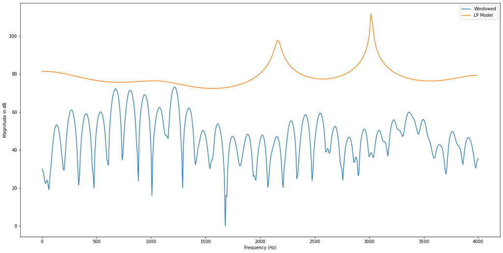

```python
plt.rcParams["figure.figsize"] = [20, 10]
P=[2,4,6,8,10]
for p in P:
    print("For LP order",p)
    print("Gain is ",C1[p])
    print("LP coefficients")
    print(a1[p])
    a1[p][1:len(a1[p])] = -a1[p][1:len(a1[p])]
    w1, h1 = freqz(C1[p], a1[p], None, 1)
    plt.plot(r,magnitude)                              #plot of magnitude spectrum of the pre-emphasized windowed signal
    plt.plot(w1[:int(len(w1)/2)]*sr/(2*np.pi),20*np.log10(abs(h1[:int(len(h1)/2)])))
    plt.ylabel('Magnitude in dB')
    plt.xlabel('Frequency (Hz)')
    plt.legend(['Windowed', 'LP Model'])
    plt.show()
```

Gain and LP coefficients are shown for pole of order 2,4,6,8,10.

LPC spectrum magnitude is plotted along with the magnitude of the pre-emphasized windowed spectrum

We can obseve that for p=2,4 the spectra are moderately fitting. For p=6,10 the spectra are not fitting. For p=8 the spectra is very well fitted.

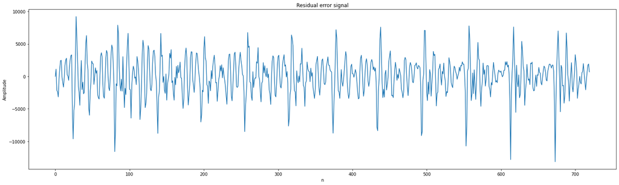

```python
plt.rcParams["figure.figsize"] = [25,7]

inverse = signal.lfilter(a1[10], C1[10], filt)
residual = filt[:] - inverse[:]
plt.plot(residual)
plt.title('Residual error signal')
plt.ylabel('Amplitude')
plt.xlabel('n')
plt.show()
```

Inverse filter is applied and residual error signal is found

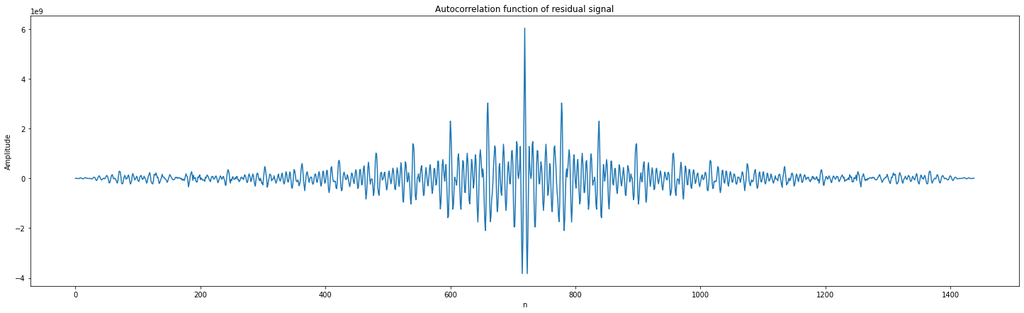

```python
acf=np.correlate(residual,residual,mode = 'full')
plt.plot(acf)
plt.title('Autocorrelation function of residual signal')
plt.ylabel('Amplitude')
plt.xlabel('n')
```

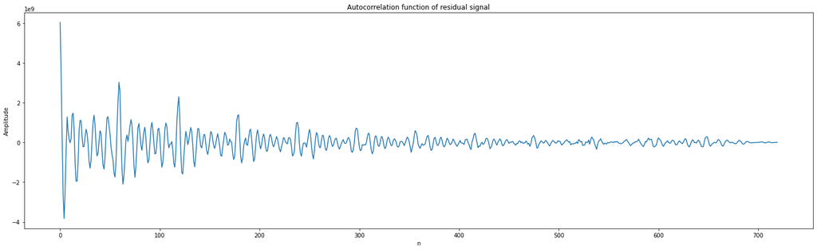

```python
acf=acf[-len(residual):len(acf)]
plt.plot(acf)
plt.title('Autocorrelation function of residual signal')
plt.ylabel('Amplitude')
plt.xlabel('n')
```

Autocorrelation function is applied on the residual signal which can be used to find the pitch.

The first plot is plotted over the whole interval and the second one is plotted for half of it to observe the peaks.

Peaks would be around T0,2T0,.... From the second plot we can observe that T0=60 i.e.,peaks are at around 60 samples interval.Sampling rate =8kHz

[figure not shown]

```python
R_or = np.correlate(data,data, mode = 'full')   #applying autocorrelation on the window obtained
plt.plot(R_or)
plt.title('autocorrelation function of the original speech')
plt.ylabel('Amplitude')
plt.xlabel('n')
```

In the autocorrelation function of residual signal peaks can be more clearly observed than in the autocorrelation function of original signal